# WK12-IP

KIPLANGAT-DAVID

January 26, 2022

**RESEARCH QUESTION**

A Kenyan entrepreneur has created an online cryptography course and would want to advertise it on her blog. She currently targets audiences originating from various countries. In the past, she ran ads to advertise a related course on the same blog and collected data in the process. She would now like to employ your services as a Data Science Consultant to help her identify which individuals are most likely to click on her ads

**METRIC FOR SUCCESS**

**THE CONTEXT** The Google Ads Auction Google Ads works on an auction system, which takes place every time a user performs a keyword search. The Google Ads auction is focused around keywords - advertisers choose a list of keywords to target that are relevant to their business offerings, the words that people are most likely to use when searching for their product. They then bid on these keywords, basing each bid on how much they are willing to pay for a Google user to click on their ad. This bid, combined with a Quality Score assigned by Google based on the quality of your proposed ad, determines which Google ads appear on the SERP. When users click the ads, the advertiser pays a certain cost (the cost per click, or CPC), which is calculated according to the below formula:

(Competitor AdRank/Your Quality Score) + 0.1

**EXPERIMENTAL DESIGN**

1. Load libraries(ggplot for visualization)
2. Load data
3. Data cleaning
4. Exploratory Data Analysis

**DATA RELEVANCE**

We are using the advertising data consisting of 10 variables: 'Daily Time Spent on Site', 'Age', 'Area Income', 'Daily Internet Usage', 'Ad Topic Line', 'City', 'Male', 'Country', Timestamp' and 'Clicked on Ad'.

The main variable we are interested in is 'Clicked on Ad'. This variable has two possible outcomes: 0 and 1 where 0 refers to the case where a user didn't click the advertisement, while 1 refers to the scenario where a user clicks the advertisement.

First, let's print our working directory

```r
getwd()
```

```
## [1] "C:/Users/WILLY KIRUI/Desktop/Ammoh/KR/DSC-R-IPs"
```

Now let's dive into our first step

**1. Import Libraries**

Here we will call the ggplot2 which will be useful in vizualisation

```r
#library('tidyverse')
library('ggplot2')
```

**2. Load Data**

Here we will read our data from the working directory using 'read.csv' because it is a csv file. We will then check top 5 and bottom 5 records.

```r
data <- read.csv("file:///C:/Users/WILLY KIRUI/Downloads/advertising.csv.csv",TRUE,",")

#preview top 5 records
head(data,5)
```

```
##   Daily.Time.Spent.on.Site Age Area.Income Daily.Internet.Usage
## 1                    68.95  35    61833.90               256.09
## 2                    80.23  31    68441.85               193.77
## 3                    69.47  26    59785.94               236.50
## 4                    74.15  29    54806.18               245.89
## 5                    68.37  35    73889.99               225.58
##                           Ad.Topic.Line           City Male    Country
## 1    Cloned 5thgeneration orchestration    Wrightburgh    0    Tunisia
## 2    Monitored national standardization      West Jodi    1      Nauru
## 3      Organic bottom-line service-desk       Davidton    0 San Marino
## 4 Triple-buffered reciprocal time-frame West Terrifurt    1      Italy
## 5         Robust logistical utilization   South Manuel    0    Iceland
##             Timestamp Clicked.on.Ad
## 1 2016-03-27 00:53:11             0
## 2 2016-04-04 01:39:02             0
## 3 2016-03-13 20:35:42             0
## 4 2016-01-10 02:31:19             0
## 5 2016-06-03 03:36:18             0
```

```r
#preview bottom 5 records
tail(data,5)
```

```
##      Daily.Time.Spent.on.Site Age Area.Income Daily.Internet.Usage
## 996                     72.97  30    71384.57               208.58
## 997                     51.30  45    67782.17               134.42
## 998                     51.63  51    42415.72               120.37
## 999                     55.55  19    41920.79               187.95
## 1000                    45.01  26    29875.80               178.35
##                             Ad.Topic.Line          City Male
## 996         Fundamental modular algorithm     Duffystad    1
## 997       Grass-roots cohesive monitoring   New Darlene    1
## 998          Expanded intangible solution South Jessica    1
## 999  Proactive bandwidth-monitored policy   West Steven    0
## 1000      Virtual 5thgeneration emulation   Ronniemouth    0
##                     Country           Timestamp Clicked.on.Ad
## 996                 Lebanon 2016-02-11 21:49:00             1
## 997  Bosnia and Herzegovina 2016-04-22 02:07:01             1
## 998                Mongolia 2016-02-01 17:24:57             1
## 999               Guatemala 2016-03-24 02:35:54             0
## 1000                 Brazil 2016-06-03 21:43:21             1
```

- Our dataset records contain our relevant advertising records and therefore relevant for our study.

Let's check dataset class

```r
#check data class
class(data)
```

```
## [1] "data.frame"
```

- Our dataset is stored in a dataframe as you can see above.

Proceed and check number rows and columns

```r
#check shape of the data
print(nrow(data))
```

```
## [1] 1000
```

```r
print(ncol(data))
```

```
## [1] 10
```

- Our dataset has 1000 rows and columns. Let's check datatypes to get more insights

```r
#check data types
str(data)
```

```
## 'data.frame':    1000 obs. of  10 variables:
##  $ Daily.Time.Spent.on.Site: num  69 80.2 69.5 74.2 68.4 ...
##  $ Age                     : int  35 31 26 29 35 23 33 48 30 20 ...
##  $ Area.Income             : num  61834 68442 59786 54806 73890 ...
##  $ Daily.Internet.Usage    : num  256 194 236 246 226 ...
##  $ Ad.Topic.Line           : chr  "Cloned 5thgeneration orchestration" "Monitored national standardization" "Organic bottom-line service-desk" "Triple-buffered reciprocal time-frame" ...
##  $ City                    : chr  "Wrightburgh" "West Jodi" "Davidton" "West Terrifurt" ...
##  $ Male                    : int  0 1 0 1 0 1 0 1 1 1 ...
##  $ Country                 : chr  "Tunisia" "Nauru" "San Marino" "Italy" ...
##  $ Timestamp               : chr  "2016-03-27 00:53:11" "2016-04-04 01:39:02" "2016-03-13 20:35:42" "2016-01-10 02:31:19" ...
##  $ Clicked.on.Ad           : int  0 0 0 0 0 0 0 1 0 0 ...
```

- Our dataset has:
  - 3 numeric variables
  - 3 integer variables
  - 4 character variables
- They are in correct datatype format and therefore no need of conversion.

Let's jump to the next step.

**2. Data Cleaning**

Here we will: 1. rename columns 2. missing values 3. duplicates 4. outliers 5. anomalies

**2.1 Renaming columns**

```r
#renane columns
names(data)[1] <- "daily_time_on_site"
names(data)[2] <- "age"
names(data)[3] <- " area_income"
names(data)[4] <- "daily_internet_usage"
names(data)[5] <- "ad_topic_line"
names(data)[6] <- "city"
names(data)[7] <- "male"
names(data)[8] <- "country"
names(data)[9] <- "timestamp"
names(data)[10] <- "clicked_on_ad"

#check whether our columns were renamed
print(head(data,3))
```

```
##   daily_time_on_site age  area_income daily_internet_usage
## 1              68.95  35     61833.90               256.09
## 2              80.23  31     68441.85               193.77
## 3              69.47  26     59785.94               236.50
##                        ad_topic_line        city male    country
## 1 Cloned 5thgeneration orchestration Wrightburgh    0    Tunisia
## 2 Monitored national standardization   West Jodi    1      Nauru
## 3   Organic bottom-line service-desk    Davidton    0 San Marino
##             timestamp clicked_on_ad
## 1 2016-03-27 00:53:11             0
## 2 2016-04-04 01:39:02             0
## 3 2016-03-13 20:35:42             0
```

- Our columns were successfully renamed

**2.2 Missing values**

```r
#check missing values
sum(is.na(data))
```

```
## [1] 0
```

- Our dataset has no missing values

**2.3 Duplicates**

```r
sum(duplicated(data))
```

```
## [1] 0
```

- There are also no duplicates

**2.4 Outliers** We will plot boxplot to visualize outliers for the numerical & integer continous variables and deal with them if any

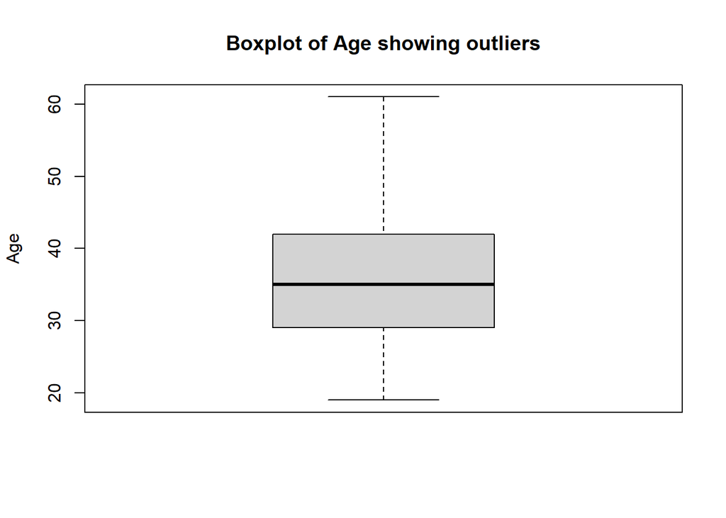

```r
#Age column
boxplot(data$age,
  ylab = "Age",
  main = "Boxplot of Age showing outliers")
```

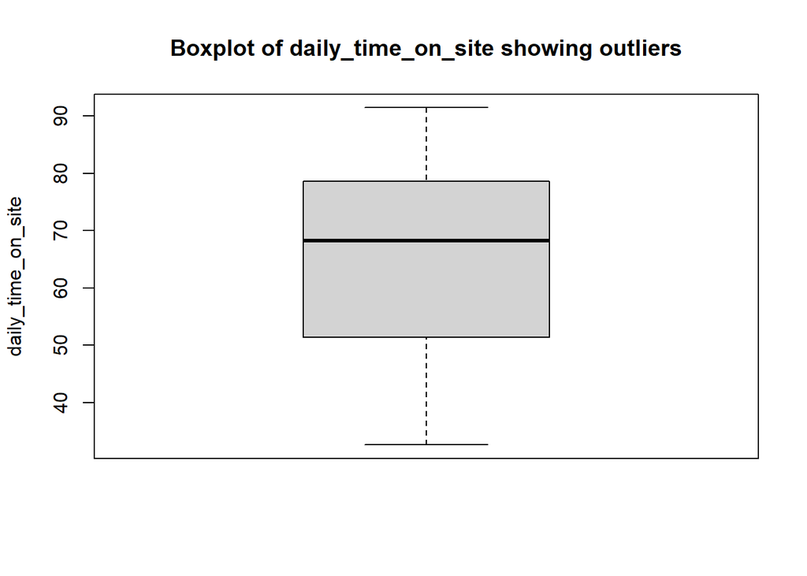

```r
#Daily_time_on_site
boxplot(data$daily_time_on_site, ylab = "daily_time_on_site",main = "Boxplot of daily_time_on_site showing outliers", fill = "blue")
```

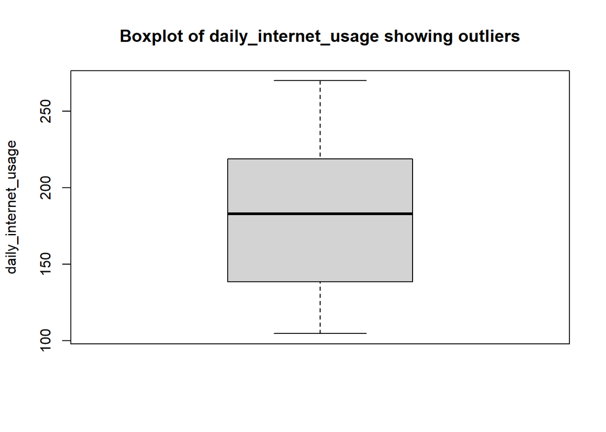

```r
#,data$area_income,
#out <- boxplot.stats(data$daily_time_on_site)$out
boxplot(data$daily_internet_usage,ylab = "daily_internet_usage",main = "Boxplot of daily_internet_usage showing outliers")
```

- The boxplots shows that our dataset has no outliers.

**2.5 Anomalies** An anomaly refers to data points in data that do not fit the normal patterns. The boxplots above shows no presence of anomalies.

Let's proceed to exploratory data analysis

**3. Exploratory Data Analysis**

Here we will do: 1. summary statistics 2. Univariate analysis 3. Bivariate analysis

**3.1 Summary statistics**

```r
#summary statistics
summary(data)
```

```
##  daily_time_on_site      age          area_income   daily_internet_usage
##  Min.   :32.60      Min.   :19.00   Min.   :13996   Min.   :104.8
##  1st Qu.:51.36      1st Qu.:29.00   1st Qu.:47032   1st Qu.:138.8
##  Median :68.22      Median :35.00   Median :57012   Median :183.1
##  Mean   :65.00      Mean   :36.01   Mean   :55000   Mean   :180.0
##  3rd Qu.:78.55      3rd Qu.:42.00   3rd Qu.:65471   3rd Qu.:218.8
##  Max.   :91.43      Max.   :61.00   Max.   :79485   Max.   :270.0
##  ad_topic_line          city                male         country
##  Length:1000        Length:1000        Min.   :0.000   Length:1000
##  Class :character   Class :character   1st Qu.:0.000   Class :character
##  Mode  :character   Mode  :character   Median :0.000   Mode  :character
##                                        Mean   :0.481
##                                        3rd Qu.:1.000
##                                        Max.   :1.000
##   timestamp         clicked_on_ad
##  Length:1000        Min.   :0.0
##  Class :character   1st Qu.:0.0
##  Mode  :character   Median :0.5
##                     Mean   :0.5
##                     3rd Qu.:1.0
##                     Max.   :1.0
```

- Minimum age is 19, mean is 36/01 and maximum age is 61. This means that the site is visited by adult users.
- The minimum area income is 13,996 and the maximum is 79,485. This means that individuals who visit the site are people belonging to different social classes
- Daily internet usage is between 104.8 and 270.0
- Individuals spend between 32 and 91 minutes on the website in one session. This must be a popular website

Now let's print most searched keyword. We will do so by printing mode of 'ad_topic_line' column

```r
#mode
#
getmode <- function(v) {
   uniqv <- unique(v)
   uniqv[which.max(tabulate(match(v, uniqv)))]
}

# Calculating the mode using out getmode() function
# ---
city_mode <- getmode(data$city)
topic <- getmode(data$ad_topic_line)
print(topic)
```

```
## [1] "Cloned 5thgeneration orchestration"
```

**3.2 Univariate Analysis**

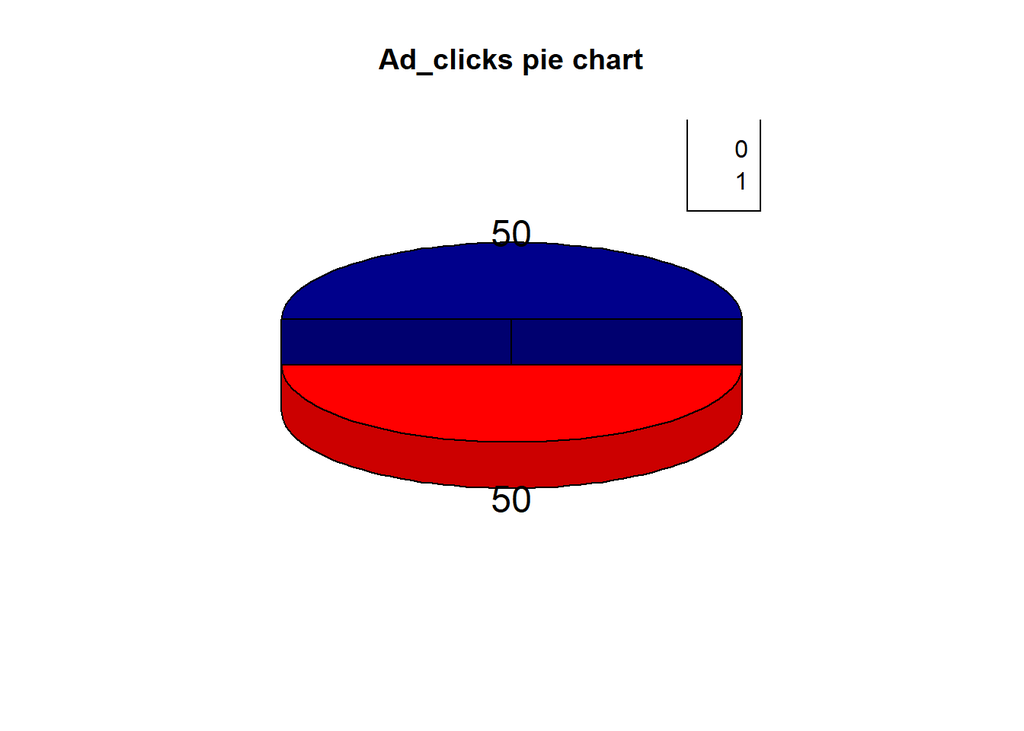

```r
# Distribution of ad_clicks.
library(plotrix)
clicks <- table(data$clicked_on_ad)
piepercent<- round(100 * clicks / sum(clicks), 2)

# Plot the chart.
pie3D(clicks, labels = piepercent,
    main = "Ad_clicks pie chart", explode =0.2,col = c('darkblue','red'))
legend("topright", c("0", "1"))
```

- 0 means an advert was not clicked and 1 means an advert was clicked by a user. They have equal distributions of 50 percent each.

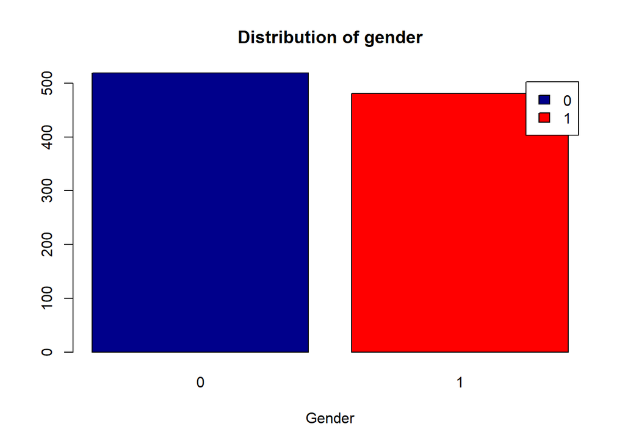

```r
#Gender distribution
gender <- table(data$male)
barplot(gender, main="Distribution of gender",
  xlab="Gender", col=c("darkblue","red"),
  legend = rownames(clicks), beside=TRUE)
```

- Here, 0-female and 1-male. - There are slightly more women visting the site than men

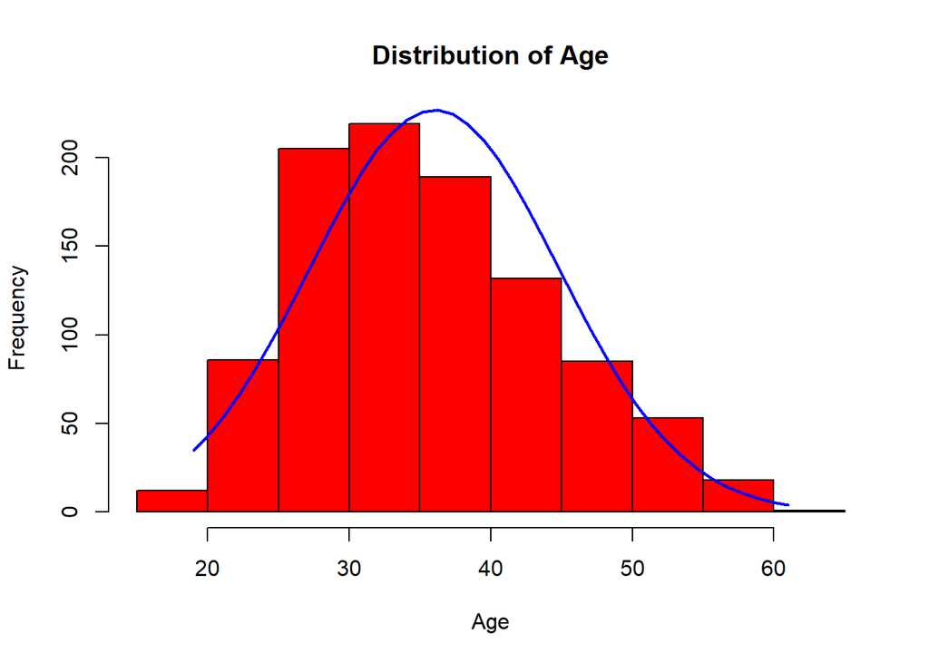

```r
# Distribution of age
x <- data$age
h<-hist(x, breaks=10, col="red", xlab="Age",
   main="Distribution of Age")
xfit<-seq(min(x),max(x),length=40)
yfit<-dnorm(xfit,mean=mean(x),sd=sd(x))
yfit <- yfit*diff(h$mids[1:2])*length(x)
lines(xfit, yfit, col="blue", lwd=2)
```

- The distribution is normal with range between 19 and 61 years

**3.3 Bivariate Analysis**

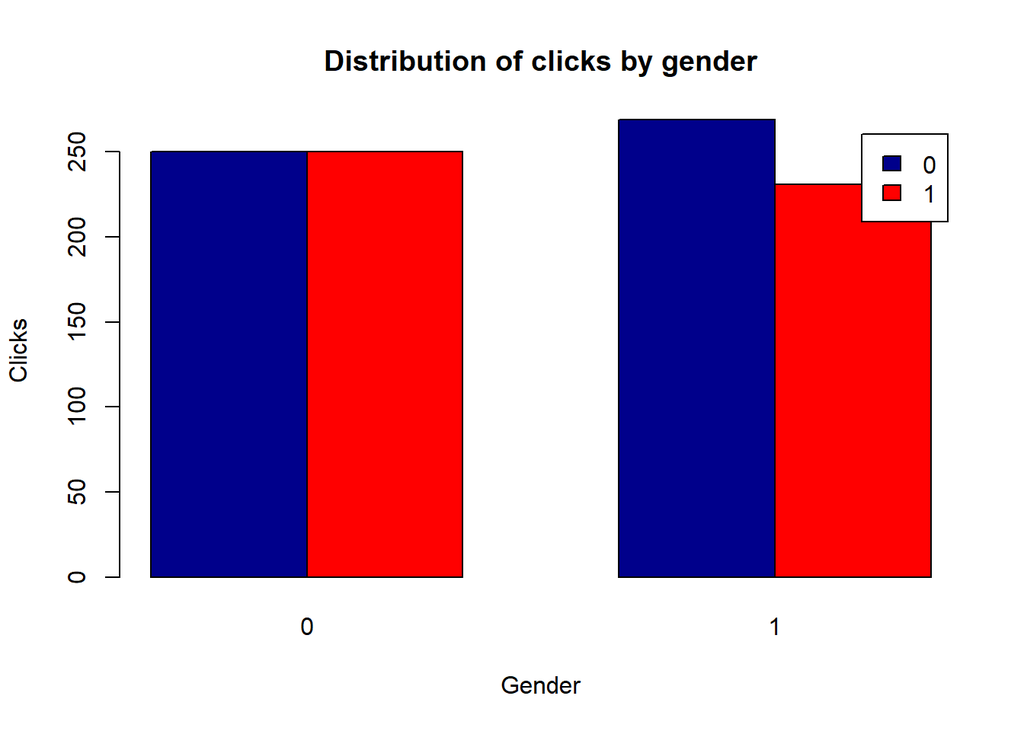

```r
# Distribution of clicks by gender
counts <- table(data$male, data$clicked_on_ad)
barplot(counts, main="Distribution of clicks by gender",
  xlab="Gender",ylab="Clicks", col=c("darkblue","red"),
  legend = rownames(counts), beside=TRUE)
```

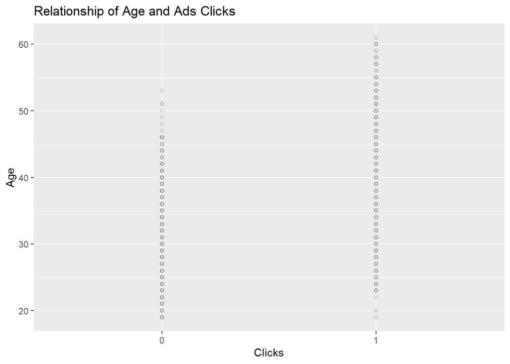

```r
#relationshiop between age and ad clicks
ggplot(aes(y = age, x = as.factor(clicked_on_ad)), data = data) +
  geom_point(alpha = 0.4, pch = 1) +
  geom_smooth(method = loess) +
  labs(y= 'Age',
       x= 'Clicks',
       title= 'Relationship of Age and Ads Clicks',col='blue')
```

-Older people clicks the ad more than younger people

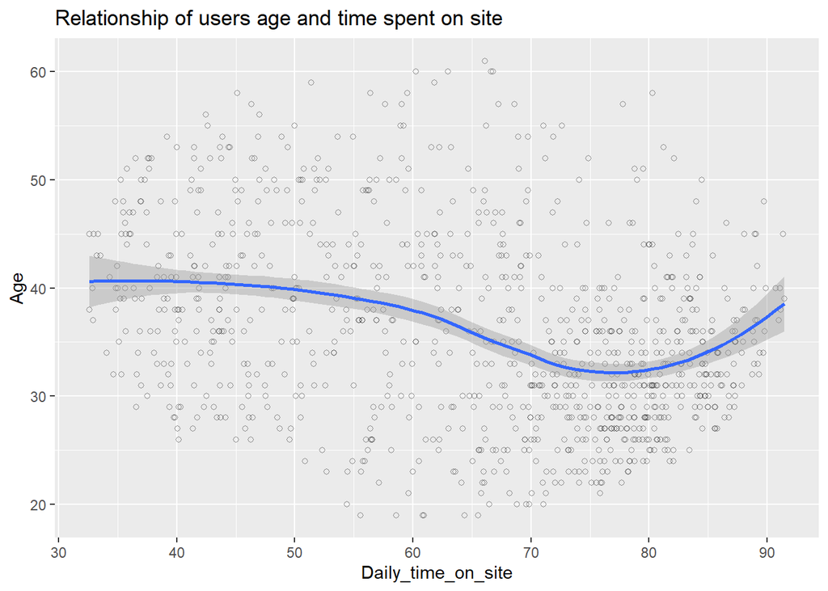

```r
ggplot(aes(y = age, x = daily_time_on_site), data = data) +
  geom_point(alpha = 0.4, pch = 1) +
  geom_smooth(method = loess) +
  labs(y= 'Age',
       x= 'Daily_time_on_site',
       title= 'Relationship of users age and time spent on site')
```

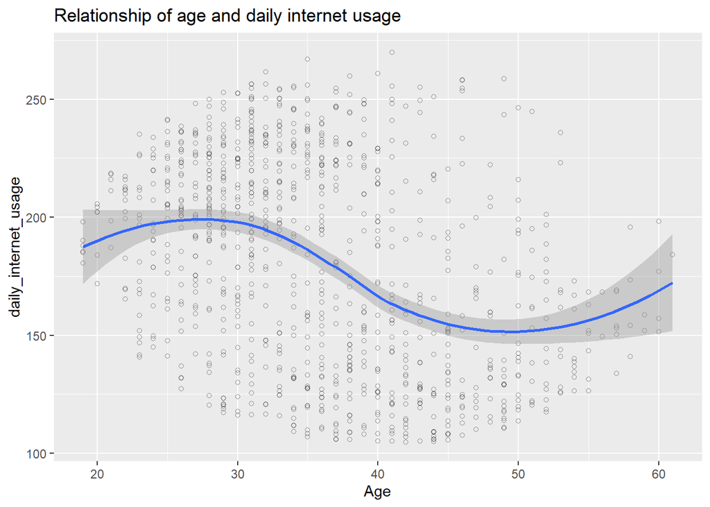

```r
#relationship of age and daily internet usage
ggplot(aes(y = daily_internet_usage, x = age), data = data) +
  geom_point(alpha = 0.4, pch = 1) +
  geom_smooth(method = loess) +
  labs(y= 'daily_internet_usage',
       x= 'Age',
       title= 'Relationship of age and daily internet usage')
```

- Young people aged 19-40 spent more internet on average compared to older people aged 40-61

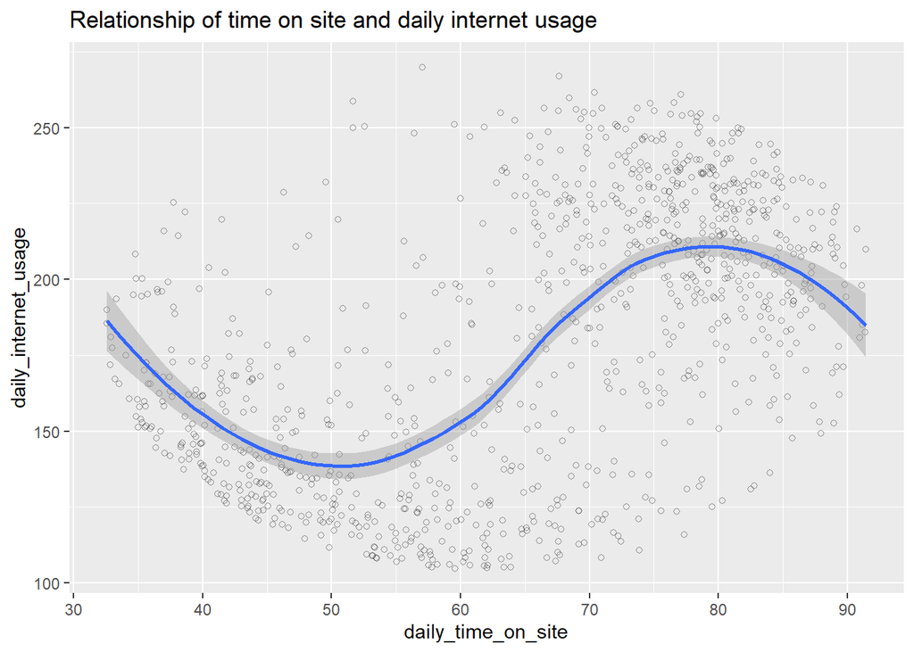

```r
#relationship between internet usage and the daily time on site
ggplot(aes(y = daily_internet_usage, x = daily_time_on_site), data = data) +
  geom_point(alpha = 0.4, pch = 1) +
  geom_smooth(method = loess) +
  labs(y= 'daily_internet_usage',
       x= 'daily_time_on_site',
       title= 'Relationship of time on site and daily internet usage')
```

- internet usage is higher in average with increased time on site

**Correlation**

```r
#correlation between daily time on site and ad clicks
corr <-cor.test(data$daily_time_on_site, data$clicked_on_ad,  method = "spearman")
corr
```

```
##
##  Spearman's rank correlation rho
##
## data:  data$daily_time_on_site and data$clicked_on_ad
## S = 290811798, p-value < 2.2e-16
## alternative hypothesis: true rho is not equal to 0
## sample estimates:
##        rho
## -0.7448725
```

- The p-value of the test is < 2.2e-16, which is less than the significance level alpha = 0.05. We can conclude that time on site and click_on_ad are significantly correlated with a correlation coefficient of -0.7448725 .

```r
#correlation between age and ad clicks
corr <-cor.test(data$age, data$clicked_on_ad,  method = "spearman")
corr
```

```
##
##  Spearman's rank correlation rho
##
## data:  data$age and data$clicked_on_ad
## S = 85610359, p-value < 2.2e-16
## alternative hypothesis: true rho is not equal to 0
## sample estimates:
##       rho
## 0.4863373
```

**4. Conclusion**

- 50% of individuals who visit the site clicks the ad and 50% do not
- More female individuals visits the site and clicks the ad as well compared to male individuals
- Aged individuals who visit the site clicks the ad more compared to younger individuals aged 40 and below.
- Younger individuals spent more time on the internet as well as internet usage

**5. Recommendation**

- Creat ads that are relevant and directly address different individuals such as male,female,young and old, social classes etc
- Compute correlation of variables using kendall tau which has better statistical properties compared to spearmann